# Clothing Detection Project

By: Devanshi Joshi & Samiksha Rajpal

Our project's main objective is to use computer vision algorithms to effectively and precisely identify different clothing items within photographs. Using neural network models, clothing items are be identified, categorized, and analyzed.

```python
# Importing the necessary libraries
import os
import shutil
import numpy as np
import matplotlib.pyplot as plt
import os
from tensorflow.keras.utils import image_dataset_from_directory
import tensorflow as tf
import matplotlib.image as mpimg
from PIL import Image
import pandas as pd
from tensorflow import keras
import pathlib
import random
from tensorflow.keras import layers
import plotly.express as px
```

### Spliting the data into train, test and valid datasets

```python
dataset_path = pathlib.Path('datasets')
train_ratio = 0.7
valid_ratio = 0.2

for category in ['train', 'valid', 'test']:
    os.makedirs(dataset_path / category, exist_ok=True)

def split_data(class_name):
    class_path = dataset_path / class_name
    images = os.listdir(class_path)
    random.shuffle(images)

    train_size = int(len(images) * train_ratio)
    valid_size = int(len(images) * valid_ratio)

    for i, image in enumerate(images):
        if i < train_size:
            target_folder = 'train'
        elif i < train_size + valid_size:
            target_folder = 'valid'
        else:
            target_folder = 'test'

        target_path = dataset_path / target_folder / class_name
        os.makedirs(target_path, exist_ok=True)
        try:
            shutil.copy(class_path / image, target_path / image)
        except PermissionError:
            print(f"Permission denied for {image}. Skipping...")

# Apply the split function to each class folder
for class_name in os.listdir(dataset_path):
    if os.path.isdir(dataset_path / class_name):
        split_data(class_name)

print("Data split into train, valid, and test folders.")
```

[output not shown]

The permission denied exception block has been implmented as this is a random error. Even with the permission denied the images are being assigned properly to their respective split in the directory.

### Loading the data

```python
data_folder = pathlib.Path('datasets')

train_dataset = image_dataset_from_directory(
    data_folder / "train",
    image_size=(180, 180),
    batch_size=32,
    label_mode='categorical')
validation_dataset = image_dataset_from_directory(
    data_folder / "valid",
    image_size=(180, 180),
    batch_size=32,
        label_mode='categorical')
test_dataset = image_dataset_from_directory(
    data_folder / "test",
    image_size=(180, 180),
    batch_size=32,
        label_mode='categorical')
```

```
Found 5107 files belonging to 20 classes.
Found 1457 files belonging to 20 classes.
Found 741 files belonging to 20 classes.
```

Here, the classes displayed are 20 but in reality the number of classes is 17 as there was a redundancy in the datasets during the creation and the split. The redundancy has been removed so the number of classes that will be classified are 17.

### Looking at some of the images from the dataset

[figure not shown]

```python
def show_batch(image_batch, label_batch, class_names):
    plt.figure(figsize=(10, 10))
    for n in range(9):
        ax = plt.subplot(3, 3, n + 1)
        plt.imshow(image_batch[n].numpy().astype("uint8"))
        label_index = np.argmax(label_batch[n])
        plt.title(class_names[label_index])
        plt.axis("off")

# Assuming `train_dataset` is your dataset
class_names = train_dataset.class_names

image_batch, label_batch = next(iter(train_dataset))
show_batch(image_batch, label_batch, class_names)
```

Based on the above images we can observe that some images do not include any model or any person and some images do. These type of different images provide a better training for the model to learn the dimensions and pixels of the clothing in different angles, with and without a model/person.

### Downloading the VGG16 Model without the head layers

```python
conv_base = keras.applications.vgg16.VGG16(
    weights="imagenet",
    include_top=False,
    input_shape=(180, 180, 3))
```

```python
conv_base.summary()
```

```
Model: "vgg16"
_________________________________________________________________
 Layer (type)                Output Shape              Param #
=================================================================
 input_1 (InputLayer)        [(None, 180, 180, 3)]     0

 block1_conv1 (Conv2D)       (None, 180, 180, 64)      1792

 block1_conv2 (Conv2D)       (None, 180, 180, 64)      36928

 block1_pool (MaxPooling2D)  (None, 90, 90, 64)        0

 block2_conv1 (Conv2D)       (None, 90, 90, 128)       73856

 block2_conv2 (Conv2D)       (None, 90, 90, 128)       147584

 block2_pool (MaxPooling2D)  (None, 45, 45, 128)       0

 block3_conv1 (Conv2D)       (None, 45, 45, 256)       295168

 block3_conv2 (Conv2D)       (None, 45, 45, 256)       590080

 block3_conv3 (Conv2D)       (None, 45, 45, 256)       590080

 block3_pool (MaxPooling2D)  (None, 22, 22, 256)       0

 block4_conv1 (Conv2D)       (None, 22, 22, 512)       1180160

 block4_conv2 (Conv2D)       (None, 22, 22, 512)       2359808

 block4_conv3 (Conv2D)       (None, 22, 22, 512)       2359808

 block4_pool (MaxPooling2D)  (None, 11, 11, 512)       0

 block5_conv1 (Conv2D)       (None, 11, 11, 512)       2359808

 block5_conv2 (Conv2D)       (None, 11, 11, 512)       2359808

 block5_conv3 (Conv2D)       (None, 11, 11, 512)       2359808

 block5_pool (MaxPooling2D)  (None, 5, 5, 512)         0

=================================================================
Total params: 14,714,688
Trainable params: 14,714,688
Non-trainable params: 0
_________________________________________________________________
```

### Freezing the weights of VGG16 model

```python
conv_base.trainable = False
conv_base.summary()
```

```
Model: "vgg16"
_________________________________________________________________
 Layer (type)                Output Shape              Param #
=================================================================
 input_1 (InputLayer)        [(None, 180, 180, 3)]     0

 block1_conv1 (Conv2D)       (None, 180, 180, 64)      1792

 block1_conv2 (Conv2D)       (None, 180, 180, 64)      36928

 block1_pool (MaxPooling2D)  (None, 90, 90, 64)        0

 block2_conv1 (Conv2D)       (None, 90, 90, 128)       73856

 block2_conv2 (Conv2D)       (None, 90, 90, 128)       147584

 block2_pool (MaxPooling2D)  (None, 45, 45, 128)       0

 block3_conv1 (Conv2D)       (None, 45, 45, 256)       295168

 block3_conv2 (Conv2D)       (None, 45, 45, 256)       590080

 block3_conv3 (Conv2D)       (None, 45, 45, 256)       590080

 block3_pool (MaxPooling2D)  (None, 22, 22, 256)       0

 block4_conv1 (Conv2D)       (None, 22, 22, 512)       1180160

 block4_conv2 (Conv2D)       (None, 22, 22, 512)       2359808

 block4_conv3 (Conv2D)       (None, 22, 22, 512)       2359808

 block4_pool (MaxPooling2D)  (None, 11, 11, 512)       0

 block5_conv1 (Conv2D)       (None, 11, 11, 512)       2359808

 block5_conv2 (Conv2D)       (None, 11, 11, 512)       2359808

 block5_conv3 (Conv2D)       (None, 11, 11, 512)       2359808

 block5_pool (MaxPooling2D)  (None, 5, 5, 512)         0

=================================================================
Total params: 14,714,688
Trainable params: 0
Non-trainable params: 14,714,688
_________________________________________________________________
```

### Data Augmentation

```python
data_augmentation = keras.Sequential(
    [
        layers.RandomFlip("horizontal"),
        layers.RandomRotation(0.1),
        layers.RandomBrightness(0.3),
        layers.RandomContrast(0.1)
    ]
)
```

### Looking at the augmented images

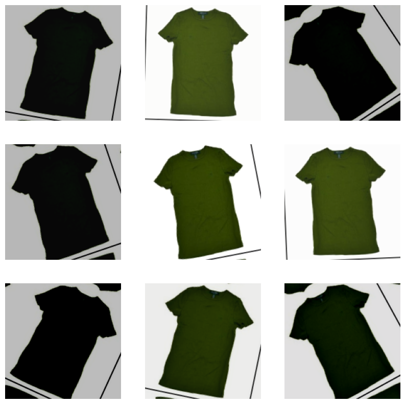

```python
plt.figure(figsize=(10, 10))
for images, _ in train_dataset.take(1):
    for i in range(9):
        augmented_images = data_augmentation(images)
        ax = plt.subplot(3, 3, i + 1)
        plt.imshow(augmented_images[0].numpy().astype("uint8"))
        plt.axis("off")
```

Here, from the above image we can observe that if we decrease the image brightness than the color of a particular clothing item may change. The color of the item in the above case is green but due to the augmentation step for brightness and contrast the augmented image seems somewhat black. This can be seen as a test case for the model to predict the color and category of cloth.

### Applying the model by implementing the vgg16 along with the head layers

### VGG16 Model-1

```python
inputs = keras.Input(shape=(180, 180, 3))
x = data_augmentation(inputs)
x = keras.applications.vgg16.preprocess_input(x)
x = conv_base(x)
x = layers.Flatten()(x)
x = layers.Dense(512, activation='relu')(x) # Layer-1 with 512 neurons and relu as the activation function
x = layers.Dropout(0.5)(x)
outputs = layers.Dense(17, activation='softmax')(x) # Classification for 17 classes
model = keras.Model(inputs, outputs)

model.compile(optimizer='adam', loss='categorical_crossentropy', metrics=['accuracy'])
```

```python
history = model.fit(
    train_dataset,
    epochs=10,
    validation_data=validation_dataset
)
```

### Metrics:

```python
test_loss, test_accuracy = model.evaluate(test_dataset)
print(f"Test accuracy: {test_accuracy*100:.2f}%")
```

```
Test accuracy: 85.43%
```

```python
import numpy as np
from tensorflow.keras.utils import to_categorical

y_pred = []
y_true = []

for image_batch, label_batch in test_dataset:
    preds = model.predict(image_batch)
    y_pred.extend(np.argmax(preds, axis=1))
    y_true.extend(np.argmax(label_batch.numpy(), axis=1))

y_pred = np.array(y_pred)
y_true = np.array(y_true)
```

```python
for images, labels in train_dataset.take(1):
    break

class_names = np.argmax(labels.numpy(), axis=1)
```

```python
from sklearn.metrics import classification_report

class_names = [f'class_{i}' for i in range(len(np.unique(y_true)))]

print(classification_report(y_true, y_pred, target_names=class_names))
```

```
              precision    recall  f1-score   support

     class_0       0.70      0.89      0.78        45
     class_1       0.73      0.93      0.82        72
     class_2       0.75      0.84      0.80        51
     class_3       0.84      0.69      0.76        75
     class_4       0.94      0.97      0.95        32
     class_5       0.96      0.98      0.97        48
     class_6       1.00      0.39      0.56        23
     class_7       0.92      0.86      0.89        14
     class_8       1.00      0.92      0.96        36
     class_9       0.87      0.52      0.65        25
    class_10       0.96      0.91      0.94        80
    class_11       0.91      0.91      0.91        32
    class_12       0.69      0.92      0.79        37
    class_13       0.97      0.97      0.97        60
    class_14       0.89      0.67      0.76        12
    class_15       0.90      0.91      0.90        57
    class_16       0.86      0.76      0.81        42

    accuracy                           0.85       741
   macro avg       0.88      0.83      0.84       741
weighted avg       0.87      0.85      0.85       741
```

With a test accuracy of 85.43% across 17 classes, the model performed quite well overall.

- **High Performance:** Several classes demonstrated exceptional precision and recall, indicating accurate and dependable forecasts for these categories. These classes include class_5, class_8, class_10, class_11, class_13, and class_15.
- **Moderate Performance:** Recall and precision for a few classes (class 0 through class 16) ranged from moderate to high, indicating good but marginally less consistent performance.
- **Difficulties in Particular Classes:** A few classes—class_6 and class_9, in particular—had good precision but noticeably poorer recall, suggesting that the model tended to overlook pertinent cases in these categories.

In conclusion, the model is doing well across all categories, with some notable exceptions. To improve overall performance, there are, nevertheless, areas for improvement in a few particular classes.

### Unfreezing some of the layers and running the model

```python
inputs = keras.Input(shape=(180, 180, 3))
x = data_augmentation(inputs)
x = keras.applications.vgg16.preprocess_input(x)
x = conv_base(x)
x = layers.Flatten()(x)
x = layers.Dense(512, activation='relu')(x) # One dense layer with 512 neurons
x = layers.Dropout(0.5)(x)
outputs = layers.Dense(17, activation='softmax')(x) # Classifying 17 classes
model1 = keras.Model(inputs, outputs)

model1.compile(optimizer='adam', loss='categorical_crossentropy', metrics=['accuracy'])
```

### Unfreezing some layers

```python
conv_base.trainable = True
for layer in conv_base.layers[:-3]:
    layer.trainable = False
```

```python
model1.compile(optimizer=keras.optimizers.Adam(learning_rate=1e-8),
              loss='categorical_crossentropy',
              metrics=['accuracy'])

history_fine = model1.fit(
    train_dataset,
    epochs=8,
    validation_data=validation_dataset
)
```

```python
test_loss, test_accuracy = model1.evaluate(test_dataset)
print(f"Test accuracy: {test_accuracy*100:.2f}%")
```

```
Test accuracy: 4.99%
```

### VGG16 Model-2

```python
inputs = keras.Input(shape=(180, 180, 3))
x = data_augmentation(inputs)
x = keras.applications.vgg16.preprocess_input(x)
x = conv_base(x)
x = layers.Flatten()(x)
x = layers.Dense(256, activation='relu')(x)
x = layers.Dense(512, activation='relu')(x)
x = layers.Dropout(0.5)(x)
outputs = layers.Dense(17, activation='softmax')(x)
model2 = keras.Model(inputs, outputs)

model2.compile(optimizer='adam', loss='categorical_crossentropy', metrics=['accuracy'])

conv_base.trainable = False
conv_base.summary()
```

```
Model: "vgg16"
_________________________________________________________________
 Layer (type)                Output Shape              Param #
=================================================================
 input_1 (InputLayer)        [(None, 180, 180, 3)]     0

 block1_conv1 (Conv2D)       (None, 180, 180, 64)      1792

 block1_conv2 (Conv2D)       (None, 180, 180, 64)      36928

 block1_pool (MaxPooling2D)  (None, 90, 90, 64)        0

 block2_conv1 (Conv2D)       (None, 90, 90, 128)       73856

 block2_conv2 (Conv2D)       (None, 90, 90, 128)       147584

 block2_pool (MaxPooling2D)  (None, 45, 45, 128)       0

 block3_conv1 (Conv2D)       (None, 45, 45, 256)       295168

 block3_conv2 (Conv2D)       (None, 45, 45, 256)       590080

 block3_conv3 (Conv2D)       (None, 45, 45, 256)       590080

 block3_pool (MaxPooling2D)  (None, 22, 22, 256)       0

 block4_conv1 (Conv2D)       (None, 22, 22, 512)       1180160

 block4_conv2 (Conv2D)       (None, 22, 22, 512)       2359808

 block4_conv3 (Conv2D)       (None, 22, 22, 512)       2359808

 block4_pool (MaxPooling2D)  (None, 11, 11, 512)       0

 block5_conv1 (Conv2D)       (None, 11, 11, 512)       2359808

 block5_conv2 (Conv2D)       (None, 11, 11, 512)       2359808

 block5_conv3 (Conv2D)       (None, 11, 11, 512)       2359808

 block5_pool (MaxPooling2D)  (None, 5, 5, 512)         0

=================================================================
Total params: 14,714,688
Trainable params: 0
Non-trainable params: 14,714,688
_________________________________________________________________
```

### Changing the learning rate as the epochs progress

```python
def lr_schedule(epoch):
    lr = 1e-3
    if epoch > 10:
        lr *= 0.5e-3
    elif epoch > 5:
        lr *= 1e-3
    elif epoch > 2:
        lr *= 1e-2
    return lr

lr_scheduler = keras.callbacks.LearningRateScheduler(lr_schedule)

model2.compile(optimizer=keras.optimizers.Adam(learning_rate=1e-3),
              loss='categorical_crossentropy',
              metrics=['accuracy'])
```

```python
history2 = model2.fit(
    train_dataset,
    epochs=10,
    validation_data=validation_dataset,
    callbacks=[lr_scheduler]
)
```

### Metrics

```python
test_loss, test_accuracy = model2.evaluate(test_dataset)
print(f"Test accuracy: {test_accuracy*100:.2f}%")
```

```
Test accuracy: 85.29%
```

```python
import numpy as np
from tensorflow.keras.utils import to_categorical

y_pred = []
y_true = []

for image_batch, label_batch in test_dataset:
    preds = model2.predict(image_batch)
    y_pred.extend(np.argmax(preds, axis=1))
    y_true.extend(np.argmax(label_batch.numpy(), axis=1))

y_pred = np.array(y_pred)
y_true = np.array(y_true)
```

```python
for images, labels in train_dataset.take(1):
    break
class_names = np.argmax(labels.numpy(), axis=1)
```

```python
from sklearn.metrics import classification_report

class_names = [f'class_{i}' for i in range(len(np.unique(y_true)))]

print(classification_report(y_true, y_pred, target_names=class_names))
```

```
              precision    recall  f1-score   support

     class_0       0.76      0.93      0.84        45
     class_1       0.86      0.79      0.83        72
     class_2       0.87      0.80      0.84        51
     class_3       0.72      0.81      0.76        75
     class_4       0.97      0.97      0.97        32
     class_5       0.96      0.94      0.95        48
     class_6       0.73      0.35      0.47        23
     class_7       0.85      0.79      0.81        14
     class_8       0.92      0.92      0.92        36
     class_9       0.63      0.76      0.69        25
    class_10       0.96      0.99      0.98        80
    class_11       0.93      0.84      0.89        32
    class_12       0.72      0.97      0.83        37
    class_13       0.94      0.98      0.96        60
    class_14       0.71      0.42      0.53        12
    class_15       0.92      0.86      0.89        57
    class_16       0.83      0.69      0.75        42

    accuracy                           0.85       741
   macro avg       0.84      0.81      0.82       741
weighted avg       0.86      0.85      0.85       741
```

The model demonstrates a great capacity to accurately classify apparel items across several classifications, as evidenced by its test accuracy of 85.29%. This high degree of accuracy suggests strong generalization and learning abilities.

The model shows a high level of proficiency in identifying different kinds of clothes. Particularly in underperforming classes, the insights from precision, recall, and F1-scores across many classes offer helpful guidance for focused improvements. The model's resilience is demonstrated by its capacity to sustain high accuracy and a favorable ratio of precision to recall in the majority of classes.

```python
from tensorflow.keras import layers, models
from tensorflow.keras.applications import ResNet50
from tensorflow.keras.optimizers import Adam
```

### ResNet50 Model

```python
def build_resnet_model(input_shape, num_classes):
    base_model = ResNet50(weights='imagenet', include_top=False, input_shape=input_shape)
    base_model.trainable = False

    inputs = tf.keras.Input(shape=input_shape)
    x = data_augmentation(inputs)
    x = base_model(x, training=False)
    x = layers.GlobalAveragePooling2D()(x)
    x = layers.Dense(1024, activation='relu')(x)
    x = layers.Dropout(0.5)(x)
    outputs = layers.Dense(num_classes, activation='softmax')(x)

    model = models.Model(inputs, outputs)
    return model

model3 = build_resnet_model((180, 180, 3), 17)
```

```python
model3.compile(optimizer=Adam(lr=0.001),
              loss='categorical_crossentropy',
              metrics=['accuracy'])
```

```
WARNING:absl:`lr` is deprecated in Keras optimizer, please use `learning_rate` or use the legacy optimizer, e.g.,tf.keras.optimizers.legacy.Adam.
```

```python
history3 = model3.fit(
    train_dataset,
    epochs=10,
    validation_data=validation_dataset
)
```

### Metrics

```python
test_loss, test_accuracy = model3.evaluate(test_dataset)
print(f"Test accuracy: {test_accuracy*100:.2f}%")
```

```
Test accuracy: 93.25%
```

```python
import numpy as np
from tensorflow.keras.utils import to_categorical

y_pred = []
y_true = []

for image_batch, label_batch in test_dataset:
    preds = model3.predict(image_batch)
    y_pred.extend(np.argmax(preds, axis=1))
    y_true.extend(np.argmax(label_batch.numpy(), axis=1))

y_pred = np.array(y_pred)
y_true = np.array(y_true)
```

```python
for images, labels in train_dataset.take(1):
    break
class_names = np.argmax(labels.numpy(), axis=1)
```

```python
from sklearn.metrics import classification_report
class_names = [f'class_{i}' for i in range(len(np.unique(y_true)))]

print(classification_report(y_true, y_pred, target_names=class_names))
```

```
              precision    recall  f1-score   support

     class_0       0.95      0.87      0.91        45
     class_1       0.89      0.99      0.93        72
     class_2       0.94      0.96      0.95        51
     class_3       0.97      0.95      0.96        75
     class_4       0.86      0.97      0.91        32
     class_5       0.98      0.94      0.96        48
     class_6       1.00      0.91      0.95        23
     class_7       0.87      0.93      0.90        14
     class_8       1.00      0.97      0.99        36
     class_9       1.00      0.76      0.86        25
    class_10       0.99      0.99      0.99        80
    class_11       1.00      0.84      0.92        32
    class_12       0.86      0.97      0.91        37
    class_13       0.94      0.97      0.95        60
    class_14       0.75      0.75      0.75        12
    class_15       0.84      1.00      0.91        57
    class_16       0.97      0.74      0.84        42

    accuracy                           0.93       741
   macro avg       0.93      0.91      0.92       741
weighted avg       0.94      0.93      0.93       741
```

The test accuracy of 93.25% indicates an excellent level of predictive accuracy across all classes. This suggests that the model is highly effective at classifying a variety of clothing items.

- **Great Precision and Recall in Many Classes:** The model can correctly identify these classes and has a low rate of false negatives and false positives. Classes like class_2, class_3, class_5, class_6, class_8, class_10, class_13, and class_15 exhibit exceptionally high precision and recall.
- **Good Balance in Most Classes:** Classes with good recall and precision ratios include class_0, class_1, class_4, class_7, and class_12. This suggests that the classes are classified effectively with little to no confusion with other classes.
- **Room for Improvement:** Recall is lower for several classes, especially class_9, class_11, and class_16, indicating that the model may occasionally overlook these classes. Despite being balanced, Class 14 has a lower score in both categories, suggesting that this class needs more improvement.

Although most courses score well in both recall and precision, there are a few where a trade-off is evident. Class_9, for example, has reduced recall but excellent precision. This could suggest that although the predictions for this class are very accurate, the model is more conservative in its predictions, which causes true positives to be missed.

When it comes to categorizing various apparel pieces, the model is doing remarkably well. Its robustness is shown by the high accuracy and balanced precision and recall in the majority of classes. On the other hand, the insights from individual class performance—especially the ones with lower recall—provide chances for focused enhancements, including more training data, feature engineering, or model tuning to better represent the traits of these particular classes.

### Model Selection

- **Accuracy**: With an accuracy of 93.25% compared to the VGG16 models' about 85%, ResNet50 performs noticeably better than both of them.
- **F1-Score, Accuracy, and Recall**:
  - Once more, ResNet50 performs better than other models with the highest F1-score, recall, and precision. This shows that it can accurately identify classes (precision) and detect the majority of positive samples (recall), which results in an F1-score that is balanced.
  - In terms of precision, recall, and F1-score, VGG16 Model 1 performs somewhat better than Model 2. This could suggest that Model 2's extra dense layer has no effect on performance in this specific test.
- **Model Choice:**

### Why ResNet50 outperforms the VGG16 Models

- The Residual Learning Architecture (ResNet) enables layers to learn from input residuals by introducing skip connections. Because of this, ResNet is far more successful at learning deep features and is easier to train than deep networks like VGG16, which frequently suffer from the vanishing gradient problem.
- Effective Depth Management: ResNet50 is more effective than VGG16, even though it is deeper (50 layers as opposed to 16). By reducing the amount of parameters through the use of global average pooling, it avoids the computational burden associated with the fully connected layers of VGG16.
- Improved Feature Learning: ResNet50's depth and design allow it to learn abstract and more complicated features, which is important for applications that call for subtle pattern recognition, including identifying complex clothing styles.
- Faster Convergence: Compared to VGG16's slower and more gradient-sensitive training procedure, ResNet's skip connections enable efficient backpropagation of gradients, resulting in faster and more stable convergence during training.
- Better Generalization: ResNet50's ability to construct intricate feature hierarchies makes it more adaptable for a wide range of applications, and it generally exhibits better generalization to a variety of datasets and workloads.
- Adaptability and Modification Ease: ResNet50's architecture facilitates more adaptable changes and layer additions without substantially impacting its fundamental operations, providing increased flexibility to task-specific alterations.

### References

- **Dataset:** [Apparel Dataset](https://www.kaggle.com/datasets/kaiska/apparel-dataset/data)

Note: The original dataset on Kaggle contains around 40 classes for various clothing and various colours. For our project purpose we have created a subset of the dataset containing 17 classes only.

- **Kaggle Notebooks:**
  - Clothing Outfit Detection: https://www.kaggle.com/code/parthoece/clothing-outfit-detection
  - Image Classification w/ VGG16 weights: https://www.kaggle.com/code/pankul/image-classification-w-vgg16-weights
  - Xception + ResNet: https://www.kaggle.com/code/kabirnagpal/xception-resnet-learn-how-to-stack
- Anwar, A. (2019, June 7). The W3H of AlexNet, VGGNet, ResNet, and Inception. Towards Data Science. Retrieved from https://towardsdatascience.com/the-w3h-of-alexnet-vggnet-resnet-and-inception-7baaaecccc96
- Shah, S. R., Qadri, S., Bibi, H., Shah, S. M. W., Sharif, M. I., & Marinello, F. (2023, June 18). Comparing Inception V3, VGG 16, VGG 19, CNN, and ResNet 50: A Case Study on Early Detection of a Rice Disease. MDPI. Retrieved from https://www.mdpi.com/2073-4395/13/6/1633
- Helwan, A. (2021, March 17). Fine-tuning VGG16 to Classify Clothing. CodeProject. Retrieved from https://www.codeproject.com/Articles/5297327/Fine-tuning-VGG16-to-Classify-Clothing
- Rath, S. R. (2021, February 1). Multi-Label Fashion Item Classification using Deep Learning and PyTorch. DebuggerCafe. Retrieved from https://debuggercafe.com/multi-label-fashion-item-classification-using-deep-learning-and-pytorch/